# R Notebook

## Tutorial 1: Project ACS data wrangling

Try executing each chunk by clicking the *Run* button within the chunk or by placing your cursor inside it and pressing *Cmd+Shift+Enter*.

In this Rmarkdown presentation, we will explore the 2013 American Community Survey data set.

- `knitr` and Rmarkdown
- The `dplyr` package
- The `googleVis` package

## Load the libraries and data

```r
datatable(head(acs13husa,50), options = list(scrollX=T, pageLength = 10))
```

|  | RT | SERIALNO | DIVISION | PUMA | REGION | ST | ADJHSG | ADJINC | WGTP | NP | TYPE | ACCESS | ACR | AGS | BATH | BDSP | BLD | BROADBND | BUS | COMPOTHX | CONP | DIALUP | DSL | ELEP | FIBEROP | FS | FULP | GASP | HANDHELD | … |
| --- | --- | --- | --- | --- | --- | --- | --- | --- | --- | --- | --- | --- | --- | --- | --- | --- | --- | --- | --- | --- | --- | --- | --- | --- | --- | --- | --- | --- | --- | --- |
| 1 | H | 84 | 6 | 02600 | 3 | 01 | 1000000 | 1007549 | 00000 | 01 | 3 |  |  |  |  |  |  |  |  |  |  |  |  |  |  | 2 |  |  |  | … |
| 2 | H | 154 | 6 | 02500 | 3 | 01 | 1000000 | 1007549 | 00051 | 04 | 1 | 1 | 1 |  | 1 | 03 | 02 | 2 | 2 | 2 |  | 2 | 2 | 350 | 1 | 2 | 0002 | 003 | 2 | … |
| 3 | H | 156 | 6 | 01700 | 3 | 01 | 1000000 | 1007549 | 00449 | 01 | 1 | 3 | 1 |  | 1 | 03 | 02 |  | 2 | 2 |  |  |  | 300 |  | 2 | 0002 | 003 | 2 | … |
| 4 | H | 160 | 6 | 02200 | 3 | 01 | 1000000 | 1007549 | 00016 | 03 | 1 | 3 | 3 | 1 | 1 | 04 | 02 |  | 2 | 2 |  |  |  | 220 |  | 1 | 0002 | 020 | 1 | … |
| 5 | H | 231 | 6 | 02400 | 3 | 01 | 1000000 | 1007549 | 00052 | 01 | 1 | 3 |  |  | 1 | 01 | 05 |  |  | 2 |  |  |  | 060 |  | 1 | 0001 | 003 | 2 | … |
| 6 | H | 286 | 6 | 00900 | 3 | 01 | 1000000 | 1007549 | 00076 | 01 | 1 | 1 | 1 |  | 1 | 04 | 02 | 2 | 2 | 2 |  | 2 | 2 | 100 | 2 | 2 | 0002 | 090 | 2 | … |
| 7 | H | 312 | 6 | 00700 | 3 | 01 | 1000000 | 1007549 | 00046 | 02 | 1 | 1 | 1 |  | 1 | 05 | 02 | 1 | 2 | 1 |  | 2 | 1 | 240 | 2 | 2 | 0002 | 003 | 1 | … |
| 8 | H | 316 | 6 | 02200 | 3 | 01 | 1000000 | 1007549 | 00036 | 02 | 1 | 1 | 2 | 1 | 1 | 03 | 02 | 2 | 2 | 2 |  | 2 | 2 | 130 | 2 | 2 | 0002 | 040 | 1 | … |
| 9 | H | 335 | 6 | 01700 | 3 | 01 | 1000000 | 1007549 | 00128 | 01 | 1 | 1 |  |  | 1 | 01 | 05 | 2 |  | 2 |  | 2 | 2 | 130 | 2 | 2 | 0002 | 003 | 2 | … |
| 10 | H | 447 | 6 | 02400 | 3 | 01 | 1000000 | 1007549 | 00138 | 02 | 1 | 1 | 2 | 1 | 1 | 03 | 02 | 2 | 2 | 2 |  | 1 | 2 | 080 | 2 | 2 | 0002 | 280 | 1 | … |

[output cut: 40 more lines]

## Basic information about data

```r
dim(acs13husa)
```

```
[1] 756065    231
```

## Using survey weights

- In this data set, there are some weight variables.
- This is because American Community Survey is based on a stratified household sample, rather than a simple random sample.
- To adjust for the unequal selection probability of individuals, weights are introduced.
- We should use `WGTP` for estimates.
- And use weight replicates `wgtp1`-`wgtp80` for standard error estimates.
- Reference: https://usa.ipums.org/usa/repwt.shtml

## The `dplyr` package

Dplyr aims to provide a function for each basic verb of data manipulation.

- `filter()`
- `arrange()`
- `select()`
- `distinct()`
- `mutate()`
- `summarise()`
- `sample_n()` and `sample_frac()`

## Add state names and abbreviations

```r
ST.anno=read_csv("../data/statenames.csv")
ST.anno=mutate(ST.anno, STabbr=abbr, STname=name)
acs13husa=mutate(acs13husa, STnum=as.numeric(ST))
acs13husa <- left_join(acs13husa, ST.anno, by = c("STnum" = "code"))
select(sample_n(acs13husa,5), starts_with("ST"))
```

| ST | STOV | STnum | STabbr | STname |
| --- | --- | --- | --- | --- |
| 19 | 1 | 19 | IA | Iowa |
| 06 | 1 | 6 | CA | California |
| 12 | 1 | 12 | FL | Florida |
| 18 | 1 | 18 | IN | Indiana |
| 06 | 1 | 6 | CA | California |

The above codes were contributed by Arnold Chua Lau (Spring 2016).

## Pipeline operator

The same codes above can be re-arranged using the pipeline operator `%>%` to improve readability of your codes.

```r
acs13husa%>%
  sample_n(5) %>%
  select(starts_with("ST"))
```

| ST | STOV | STnum | STabbr | STname |
| --- | --- | --- | --- | --- |
| 06 | 1 | 6 | CA | California |
| 06 | 1 | 6 | CA | California |
| 13 | 1 | 13 | GA | Georgia |
| 27 | 1 | 27 | MN | Minnesota |
| 13 | 1 | 13 | GA | Georgia |

## Pipeline basic analysis

Building types (BLD) 01 .Mobile home or trailer 02 .One-family house detached 03 .One-family house attached 04 .2 Apartments 05 .3-4 Apartments 06 .5-9 Apartments 07 .10-19 Apartments 08 .20-49 Apartments 09 .50 or more apartments 10 .Boat, RV, van, etc.

```r
table(acs13husa$BLD)
```

[output not shown]

```r
mobilehome=
  acs13husa %>%
  filter(BLD == "01") %>%
  group_by(STabbr) %>%
  summarize(
    AvgPrice = mean(as.numeric(MHP), na.rm=T),
    MedianPrice = as.numeric(median(as.numeric(MHP), na.rm=T)),
    Count = n()
  ) %>%
  arrange(desc(Count))
```

## Simple plot

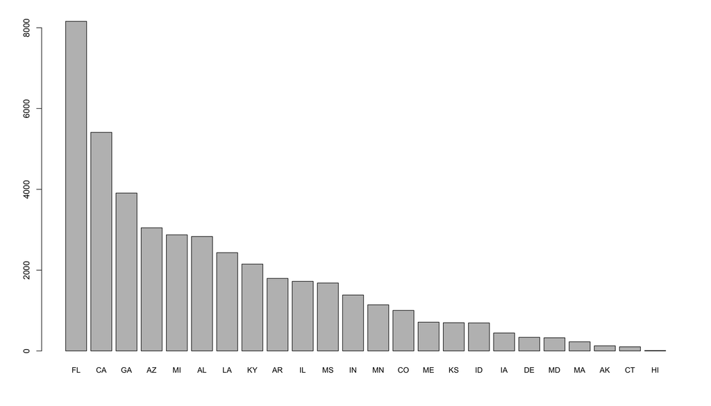

```r
barplot(mobilehome$Count, names.arg=mobilehome$STabbr,
        cex.names=0.9)
```

## Simple plot

```r
plot(c(0,nrow(mobilehome)),
     c(min(mobilehome$MedianPrice),
       max(mobilehome$MedianPrice)*1.05), type="n",
     xlab="States",
     ylab="Mobile Home Prices")
points(1:nrow(mobilehome), mobilehome$MedianPrice, col=2, pch=16)
```

```r
points(1:nrow(mobilehome), mobilehome$AvgPrice, col=4, pch=16)
segments(1:nrow(mobilehome), mobilehome$MedianPrice,
      1:nrow(mobilehome), mobilehome$AvgPrice)
```

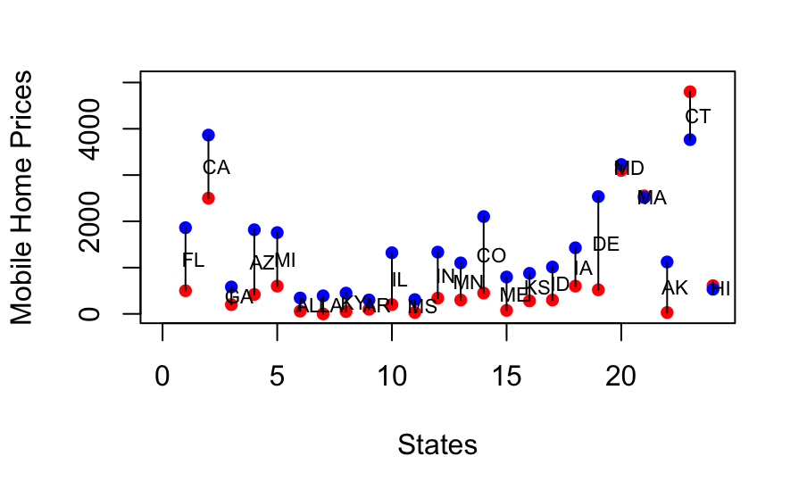

```r
text(1:nrow(mobilehome)+0.35,
     (mobilehome$MedianPrice+mobilehome$AvgPrice)/2,
     mobilehome$STabbr, cex=0.7)
```

## Put together summary data

```r
VALP.sum=summarise(group_by(acs13husa, STabbr),
                     weighted.mean(as.numeric(VALP),
                                   as.numeric(WGTP),
                                   na.rm=T))
FINCP.sum=summarise(group_by(acs13husa, STabbr),
                     weighted.mean(as.numeric(FINCP),
                                   as.numeric(WGTP), na.rm=T))
MRGP.sum=summarise(group_by(acs13husa, STabbr),
                     weighted.mean(as.numeric(MRGP),
                                   as.numeric(WGTP), na.rm=T))
sum.data=data.frame(abbr=ST.abbr,
                    VALP=unlist(VALP.sum[,2]),
                    FINCP=unlist(FINCP.sum[,2]),
                    MRGP=unlist(MRGP.sum[,2]))
sum.data[,-1]=round(sum.data[,-1], digits=2)
```

## Simple Google Visualization

We will use the `googleVis` package to achieve simple interactive visualization (it requires internet connectivity).

```r
library(googleVis)
op <- options(gvis.plot.tag='chart')
Bubble <- gvisBubbleChart(sum.data, idvar="abbr",
                          xvar="FINCP", yvar="VALP",
                          colorvar="",
                          sizevar="MRGP",
                          options=list(width="900px",
                                       height="600px",
                                       sizeAxis = '{minValue: 0,
                                       maxSize: 15}'))
```

## Simple Google Visualization

```r
plot(Bubble)
```

[output not shown]